# ANLY 545 hw2

Lianguan Zhou

2018-04-05

```r
library(tidyverse)
library(magrittr)
library(vcd)
library(vcdExtra)
library(HistData)
```

## Exercise 3.1

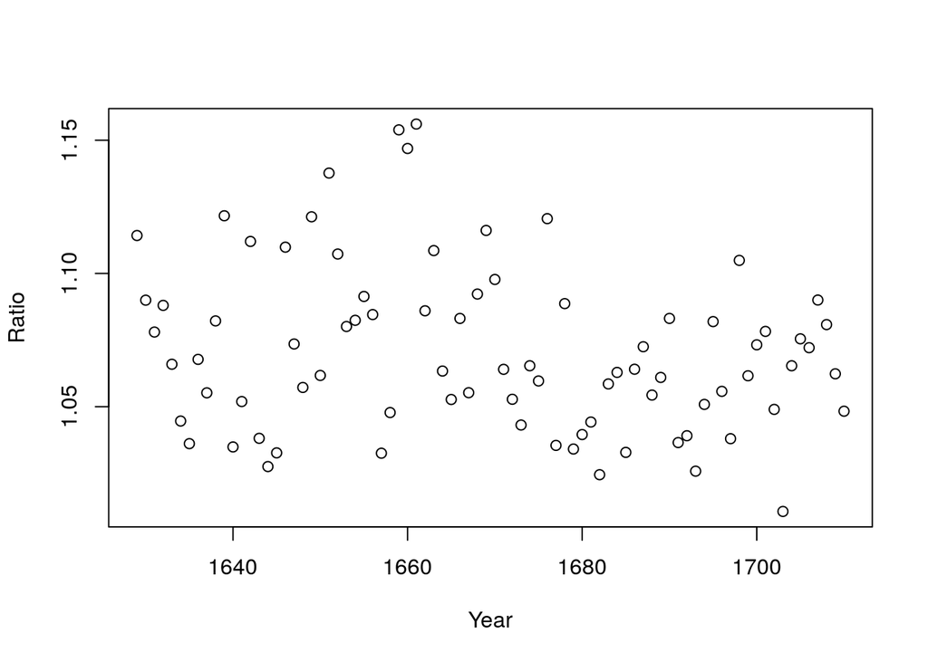

```r
arb <- HistData::Arbuthnot

# (a)
plot(Ratio ~ Year, data = arb)
```

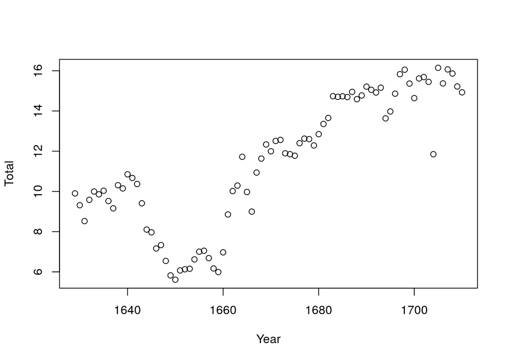

```r
# (b)
plot(Total ~ Year, data = arb)
```

The `Total` is the total christenings in London (000s), so it should closely related toe the birth. We can see that `Total` is significant decreasing between 1640 to 1660, and then had a significant increasing between 1660 to 1680, and then maintained in a relative high level. This indicates that the population birth had a fluctuation between 1640 to 1680.

## Exercise 3.4

```r
sax <- vcd::Saxony

# (a)
binorm_fit <- goodfit(sax, type = "binomial", par = list(size = 12, prob = 0.5))

# chi-square statistic
chi_sq <- sum((binorm_fit$observed - binorm_fit$fitted)^2 / binorm_fit$fitted)
# df is 12
df <- length(sax) - 1

# the ratio of chi_sq and df
chi_sq / 12
```

```
## [1] 20.76629
```

So we can see that the ratio is relative high, this may incicates that this may not be a good fit. Actually we can calculate the p value fo the goodness of the fit test:

```r
pchisq(q = chi_sq, df = 12, lower.tail = FALSE)
```

```
## [1] 2.013281e-46
```

This confirms the conclution.

The MLE of binominal distribution is $\hat{p} = x/n$, so we can calculate the $\hat{p}$.

```r
# (b)
# calculate the mle of p
nums = as.numeric(names(sax))
p_mle <- sum(nums * sax) / (12 * sum(sax))

ml_fit <- goodfit(sax, type = "binomial", par = list(size = 12, prob = p_mle))
# ml_fit <- goodfit(sax, type = "binomial", method = "ML") # also can directly set method = "ML"

# goodness of fit test
summary(ml_fit)
```

```
##
##   Goodness-of-fit test for binomial distribution
##
##                       X^2 df     P(> X^2)
## Pearson          110.5050 12 4.754460e-18
## Likelihood Ratio  97.0065 12 2.143564e-15
```

Better than use $p = 1/2$, but p value is still low. But considering the sample size, it’s ok to have a low p value.

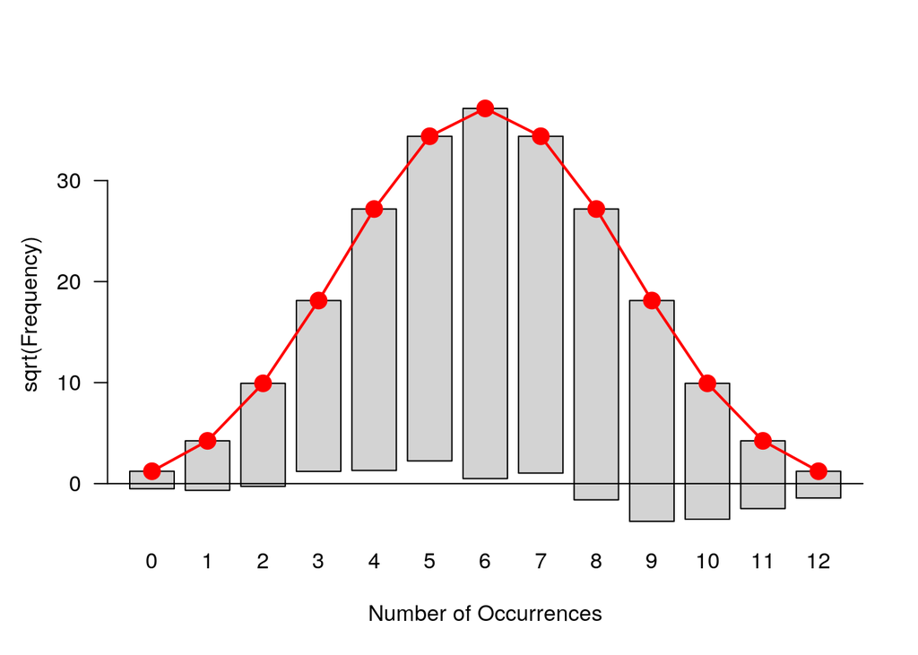

```r
# (c)
plot(binorm_fit)
```

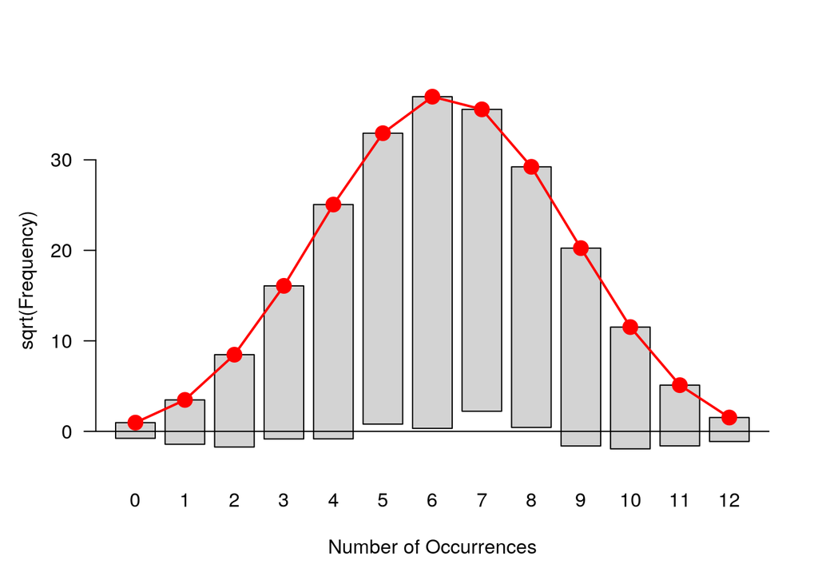

```r
plot(ml_fit)
```